# Spatial Trajectory Screening

## 1. Prerequisites

Make sure to be familiar with the following vignettes:

- Creating Spatial Trajectories

## 2. Introduction

Spatial Trajectory Screening (STS) pursues the hypothesis that specific genes - or other numeric features for that matter - display non-random expression patterns in relation to spatial reference features, such as spatial trajectories. STS utilizes these reference features to incorporate the integration of potential biological forces in the identification of spatially variable genes, such as the direction of tumorous infiltration. This allows for a supervised, hypothesis-driven screening for spatial patterns, which, unlike differential expression analysis (DEA), acknowledges the continuous nature of gene expression and avoids the limitations of group-based testing. The algorithm is wrapped up in the function `spatialTrajectoryScreening()`. See the vignette on creating spatial trajectories and using spatial trajectories for more information. Throughout the tutorial we are using the same example sample that we used in the tutorial on creating spatial trajectories - the glioblastoma sample UKF269T.

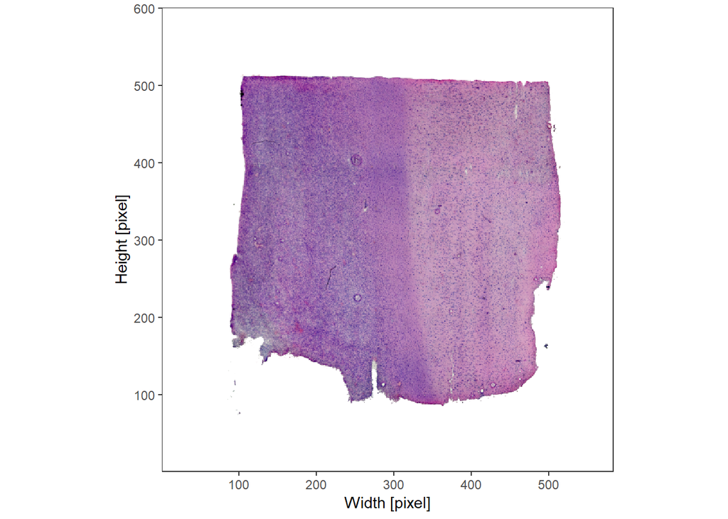

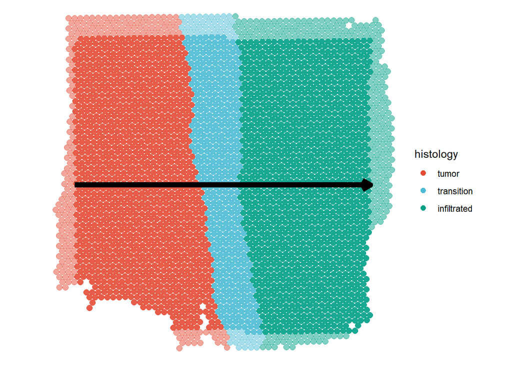

Fig.1 Example sample T269.

```r
library(SPATA2)
library(SPATAData)
library(tidyverse)

# download sample UKF269T
object_t269 <- downloadFromPublication(pub = "kueckelhaus_et_al_2024", id = "UKF269T")

# add the grouping variables if you created object_t269 yourself from raw data
data("spatial_segmentations")

object_t269 <-
  addFeatures(
    object_t269 = object_t269,
    feature_df = spatial_segmentations$UKF269T,
    overwrite = TRUE
  )

# show image
plotImage(object_t269)

# created with code
plotSpatialTrajectories(
  object = object_t269,
  ids = "horizontal_mid",
  color_by = "histology"
)
```

## 3. Run the algorithm

The function to use is called `spatialTrajectoryScreening()`. The parameter `variables` takes the numeric variables that are supposed to be included in the screening process. Since all sorts of numeric variables can be included in the screening, the argument for the input is simply called `variables`. Here, we are using the genes that were already identified as spatially variable by `SPARKX`. The goal is to further analyze which of the genes are expressed in a non-random and biologically meaningful way along the trajectory.

```r
# this is a wrapper around SPARK::sparkx()
object_t269 <- runSparkx(object = object_t269)

# keep genes with a sparkx pvalue of 0.01 or lower
spark_df <- getSparkxGeneDf(object = object_t269, threshold_pval = 0.01)

# show results
spark_df
```

| genes | combinedPval | adjustedPval |
| --- | --- | --- |
| RPL22 | 0.000000e+00 | 0.000000e+00 |
| ID3 | 0.000000e+00 | 0.000000e+00 |
| MARCKSL1 | 0.000000e+00 | 0.000000e+00 |
| PHC2 | 0.000000e+00 | 0.000000e+00 |
| RPS8 | 0.000000e+00 | 0.000000e+00 |
| WLS | 0.000000e+00 | 0.000000e+00 |
| GNG5 | 0.000000e+00 | 0.000000e+00 |
| RPL5 | 0.000000e+00 | 0.000000e+00 |
| CNN3 | 0.000000e+00 | 0.000000e+00 |
| RHOC | 0.000000e+00 | 0.000000e+00 |

[output cut: 990 more lines]

```r
# `getSparkxGenes()` would work, too
input_genes <- spark_df[["genes"]]

# define start and end positions of the trajectory directly
object_t269 <-
  addSpatialTrajectory(
    object = object_t269,
    id = id,
    start = c("1.5mm", "4mm"),
    end = c("6.5mm", "4mm"),
    overwrite = TRUE
  )

trajectory_add_on <-
  ggpLayerTrajectories(object = object_t269, ids = "horizontal_mid")

# note: the results are NOT stored in the SPATA2 object but in a separate object
sts_out <-
  spatialTrajectoryScreening(
    object = object_t269,
    id = id, # ID of the spatial trajectory
    variables = input_genes # the variables/genes to include in the screening
  )

class(sts_out)
```

**Note**: The output of `spatialTrajectoryScreening()` is **not** saved in the `SPATA2` object but returned in a separate S4 object of class `SpatialTrajectoryScreening`. Do **not** overwrite the `SPATA2` object by writing `object_t269 <- spatialTrajectoryScreening(object = object_t269, id = id, ...)`.

## 4. Results

The first step of the screening identifies pattern that are unlikely due to random gene expression. The second step fits the non-random gene expression pattern to predefined models which guides in interpretation and screening for specific gene expression pattern.

### 4.1 Non-random gene expression

Slot @significance contains a data.frame with one row for each screened variable which provides information regarding the degree of randomness the inferred pattern contains as quantified by the total variation (tot_var). The p-value gives the probability to obtain such a total variation under complete randomness and indicates the degree of significance. Column *fdr* contains the adjusted p-value according to the False Discovery Rate.

```r
sign_df <-
  sts_out@significance %>%
  filter(fdr < 0.05)

# show significance data.frame
sign_df
```

| variables | rel_var | tot_var | p_value | norm_var | fdr |
| --- | --- | --- | --- | --- | --- |
| A1BG | -0.6359148304 | 7.397313 | 0.0004 | 0.14794627 | 0.0011120357 |
| A2M | -0.4143675145 | 5.614566 | 0.0000 | 0.11229132 | 0.0000000000 |
| ABAT | -0.4002385623 | 7.982562 | 0.0012 | 0.15965123 | 0.0028277078 |
| ABCA2 | 0.0354314139 | 4.834067 | 0.0000 | 0.09668134 | 0.0000000000 |
| ABCD3 | -0.2985658214 | 9.138227 | 0.0172 | 0.18276454 | 0.0279593397 |
| ABHD17C | -0.4570125162 | 8.660461 | 0.0063 | 0.17320921 | 0.0117286567 |
| ABHD2 | -0.6060158239 | 5.797424 | 0.0000 | 0.11594847 | 0.0000000000 |
| ABI1 | -0.2930846958 | 8.110560 | 0.0017 | 0.16221120 | 0.0038647631 |
| ABL1 | -0.6988439724 | 9.163219 | 0.0181 | 0.18326437 | 0.0292066408 |
| ABR | 0.1067632088 | 6.714484 | 0.0000 | 0.13428968 | 0.0000000000 |

[output cut: 990 more lines]

```r
# extract variables names
non_random <-
  slice_min(sts_out@significance, p_value, n = 4, with_ties = F) %>%
  pull(variables)

random <-
  slice_max(sts_out@significance, p_value, n = 4, with_ties = F) %>%
  pull(variables)
```

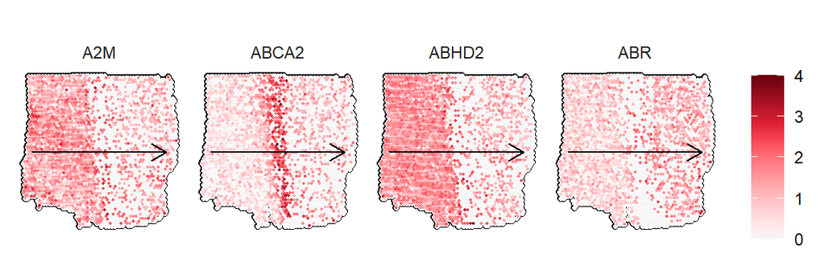

Fig.3 Surface plots of genes identified as non-random.

```r
plotSurfaceComparison(
  object = object_t269,
  color_by = non_random,
  pt_clrsp = "Reds 3",
  outline = T,
  nrow = 1
  ) +
  trajectory_add_on
```

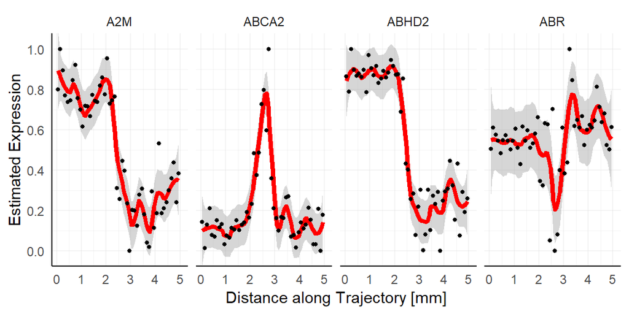

Fig.4 Lineplots of genes identified as non-random.

```r
plotStsLineplot(object_t269, variables = non_random, id = id, line_color = "red", nrow = 1) +
  geom_point(color = "black", size = 1)
```

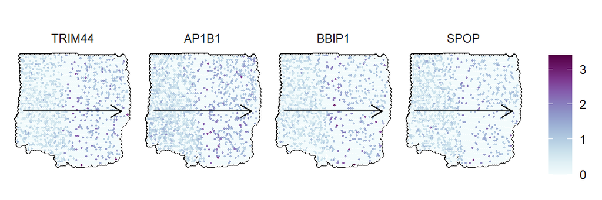

Fig.5 Surface plots of genes identified as random.

```r
plotSurfaceComparison(
  object = object_t269,
  color_by = random,
  pt_clrsp = "BuPu",
  outline = T,
  nrow = 1
  ) +
  trajectory_add_on
```

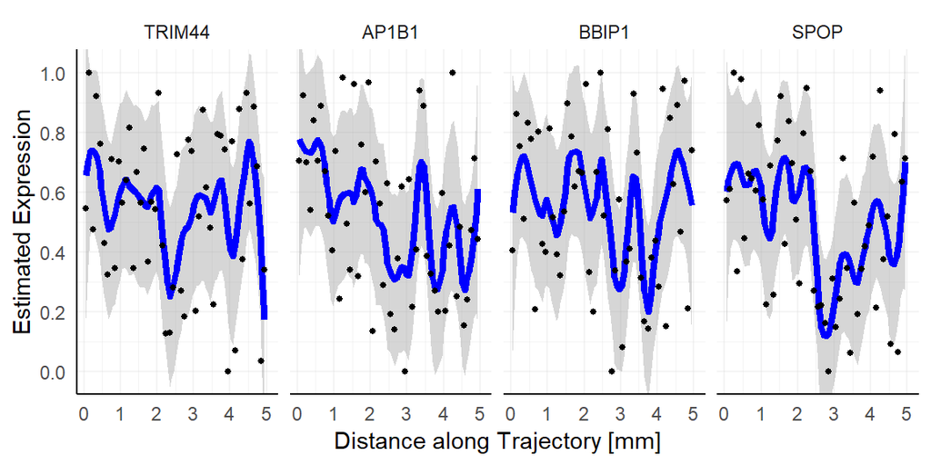

Fig.6 Lineplots of genes identified as random.

```r
plotStsLineplot(object_t269, variables = random, id = id, line_color = "blue", nrow = 1) +
  geom_point(color = "black", size = 1)
```

### 4.2 Model fits

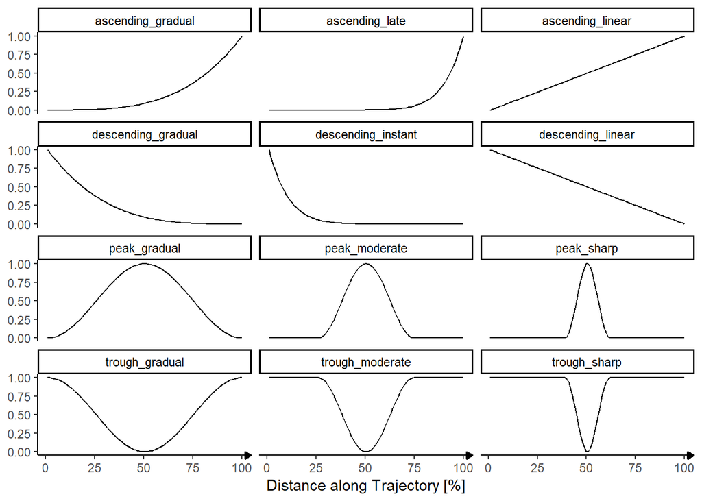

Fig.4 The predefined default models used by SPATA2.

```r
showModels(nrow = 4) +
  labs(x = "Distance along Trajectory [%]")
```

Slot @results contains the model fitting results. It is a data.frame where each row corresponds to a variable ~ model pair. The columns mae (mean absolute error) and rmse (root mean squared error) indicate the quality of the fit. The lower the value the better.

```r
best_fits <-
  sts_out@results %>%
  filter(variables %in% sign_df[["variables"]]) %>%
  group_by(variables) %>%
  slice_min(mae, n = 1)

best_fits
```

| variables | models | corr | mae | rmse |
| --- | --- | --- | --- | --- |
| A1BG | descending_linear | 0.77519537 | 0.1698916 | 0.2081294 |
| A2M | descending_linear | 0.79370337 | 0.1544162 | 0.1876246 |
| ABAT | descending_linear | 0.70221808 | 0.1720095 | 0.2123273 |
| ABCA2 | peak_sharp | 0.86409381 | 0.1422916 | 0.1649968 |
| ABCD3 | descending_linear | 0.65429349 | 0.2083011 | 0.2435405 |
| ABHD17C | descending_linear | 0.67881925 | 0.1929127 | 0.2433480 |
| ABHD2 | descending_linear | 0.83428014 | 0.1573090 | 0.1890783 |
| ABI1 | ascending_linear | 0.12759514 | 0.2726525 | 0.3306018 |
| ABL1 | descending_linear | 0.73380208 | 0.1849606 | 0.2315517 |
| ABR | ascending_linear | 0.20258394 | 0.2785520 | 0.3139148 |

[output cut: 990 more lines]

The following code chunk extracts the genes that followed each model best.

```r
best_fits_by_model <-
  group_by(best_fits, models) %>%
  slice_min(mae, n = 1) %>%
  filter(rmse < 0.2) # threshold suggestions for root mean squared error

best_fits_by_model
```

| variables | models | corr | mae | rmse |
| --- | --- | --- | --- | --- |
| VGF | ascending_gradual | 0.8305320 | 0.1099587 | 0.1718769 |
| NDRG2 | ascending_linear | 0.9128194 | 0.1021316 | 0.1329268 |
| RDH10 | descending_gradual | 0.9194126 | 0.1121110 | 0.1431687 |
| PHC2 | descending_linear | 0.8954933 | 0.1040357 | 0.1372627 |
| SELENOP | peak_moderate | 0.9354175 | 0.1042793 | 0.1299904 |
| MOBP | peak_sharp | 0.9337352 | 0.1019120 | 0.1274328 |
| CITED1 | trough_gradual | 0.8439258 | 0.1592171 | 0.1955017 |
| BSG | trough_sharp | 0.7859339 | 0.1510350 | 0.1950027 |

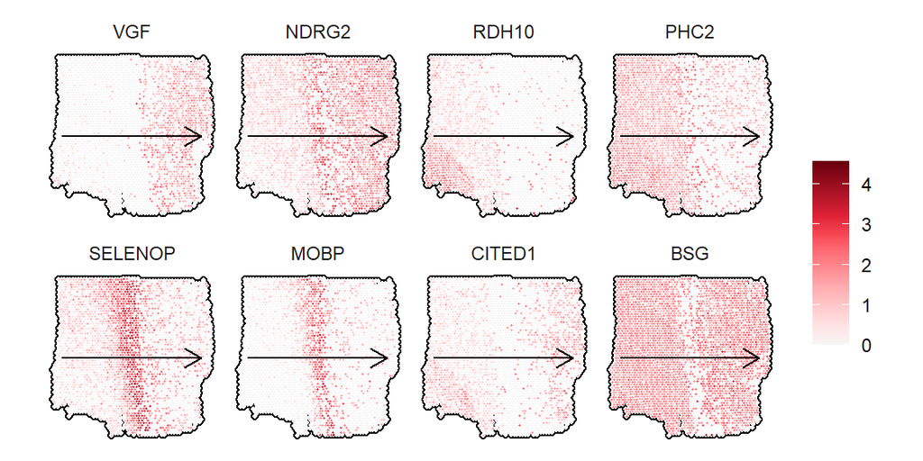

Fig.7 Surface plots of example genes that best fit each model.

```r
plotSurfaceComparison(
  object = object_t269,
  color_by = best_fits_by_model[["variables"]],
  outline = TRUE,
  display_image = FALSE,
  pt_clrsp = "Reds 3",
  nrow = 2
  ) +
  trajectory_add_on
```

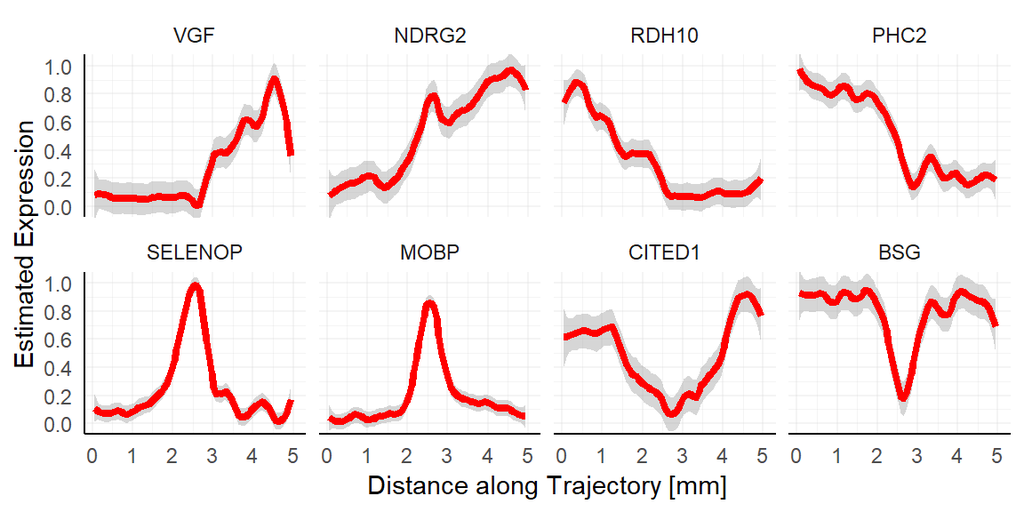

Fig.8 Lineplots of example genes that best fit each model.

```r
plotStsLineplot(
  object = object_t269,
  variables = best_fits_by_model[["variables"]],
  id = id,
  line_color = "red",
  nrow = 2
)
```